# Introdução à Linguagem R

### 5.3.4 Gráfico de barras com cores condicionadas

É possível inserir configurações condicionadas. A condição é se o lucro for negativo, a cor da barra deve ser vermelho, do contrário, deve ser azul.

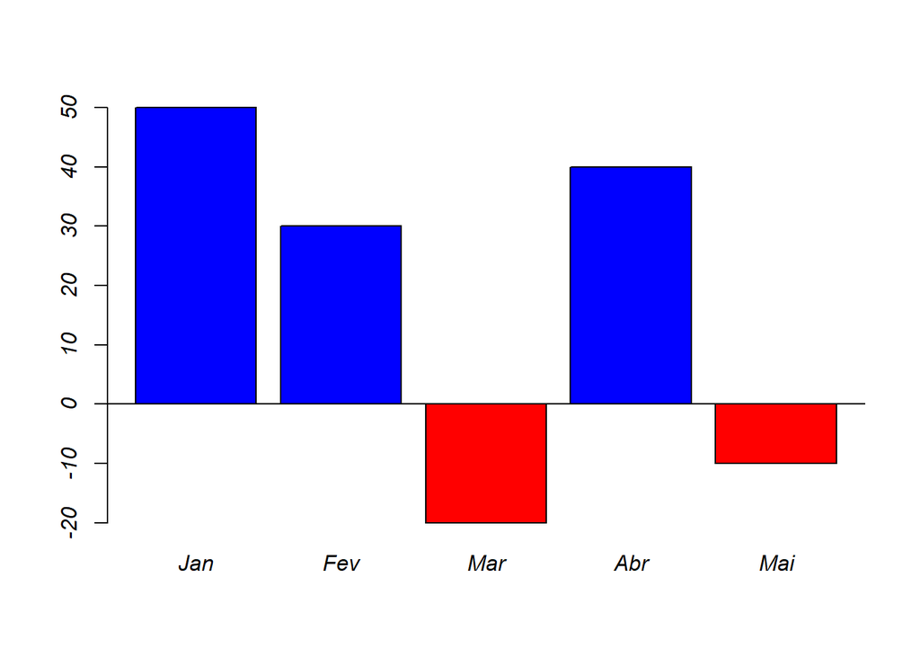

```r
lucro<-c(50,30,-20,40,-10)
mes<-c("Jan", "Fev", "Mar","Abr","Mai")

barplot(lucro, col=ifelse(lucro<0,"red","blue"), names.arg = mes, font.axis = 3)
abline(h=0)
```

### 5.3.5 configurações dos parâmetros gráficos

Há duas maneiras de alterar os parâmetros gráficos. A primeira é usado os argumentos das funções gráficas `barplot()`, `plot()` ou `hist()`, e a segunda é por meio da função `par()`. Alguns parâmetros são podem ser alteradas diretamente na função que cria o Gráfico, como os rótulos dos eixos (`xlab`), outras somente podem ser alteradas por meio do `par()`, como as margens de plotagem. A seguir, demonstra-se como alterar a cor de fundo de um gráfico.

Para exibir e alterar as configurações padrões (*default*) para os gráficos, deve usar o comando `par()`. Para exibir as configurações das cores de fundo (*background*), basta digitar `par("bg")`.

```r
par() # Exibe as configurações gráficas
par("mar") # margens região de plotagem: inferior, esquerda, superior e direita
par("bg") # cor de fundo
```

As configurações podem ser alteradas, mas para um retorno rápido ao padrão é conveniente que, primeiramente, faça-se uma cópia das configurações iniciais.

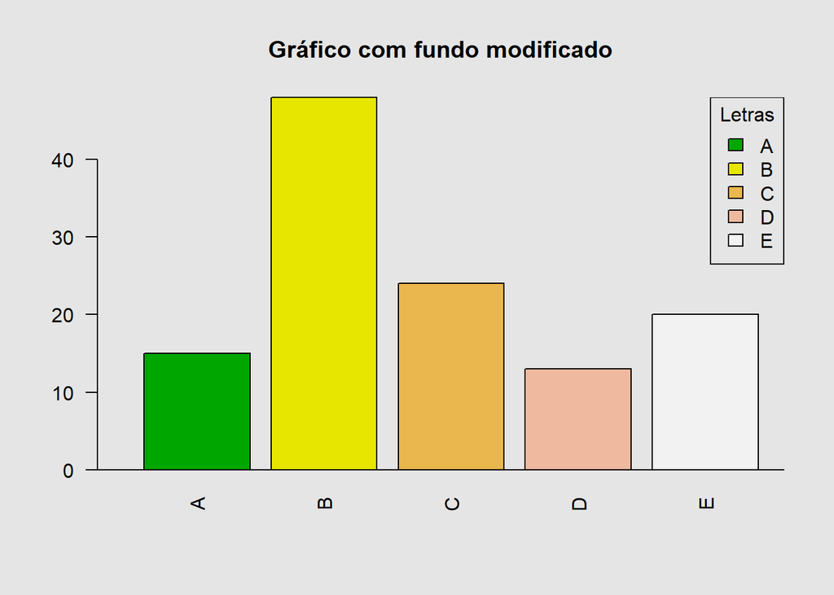

```r
par.copy<-par() # guarda as configurações default
par(bg="gray90")
barplot(x,col=terrain.colors(5),xlim=c(0,6),las=2)
legend("topright",legend=rownames(x), fill=terrain.colors(5),title="Letras")
abline(h=0)
title("Gráfico com fundo modificado")
```

## 5.4 Histograma

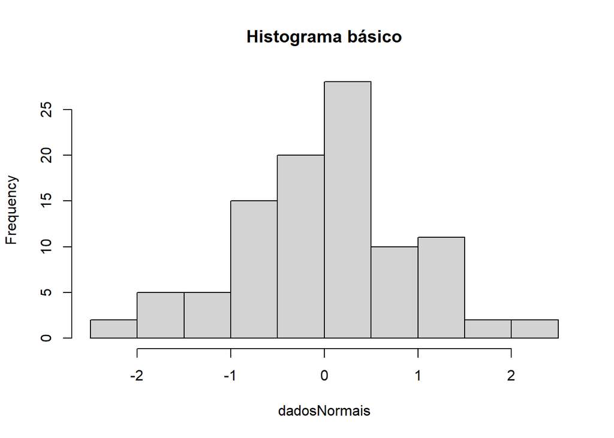

```r
dadosNormais<-rnorm(100,mean = 0,sd=1) # dados normais aleatórios

hist(dadosNormais, main = "Histograma básico") # Histograma
```

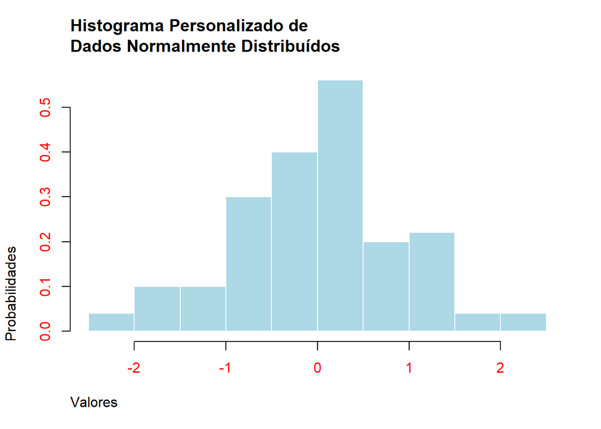

```r
hist(dadosNormais,main="Histograma Personalizado de\nDados Normalmente Distribuídos",xlab="Valores", ylab="Probabilidades",col="lightblue",border="white", prob=T,right=T, adj=0,col.axis="red")
```